# Demonstration of importing and analyzing sequence data

Suppose that we are still looking at the preweaning mortality dataset but not we have the sequences of the ORF5 gene of PRRSV

Load the necessary library

```r
## The Analyses of Phylogenetics and Evolution library is required
library(ape)
```

Read in aligned sequences in fasta format. In this case it is aligned fasta data. You may be working with a source of unaligned sequences, in with case you should aligned them first. If you are workign with character data such as MLST, MLVA, or PFGE profiles then this can be used directly here as well.

```r
a <- read.FASTA("aligned.fas")
```

Calculate a distance matrix for the sequences. If this were character data then the distance calculation would be done differently depending on the type of data.

```r
dis <- dist(a)
```

Calculate an average linkage clustering of the distance matrix An average linkage tree is analogous to a UPGMA (Unweighted Pair Group Method with Arithmetic Mean) tree. You can read about [other linkage algorithms](https://en.wikipedia.org/wiki/Hierarchical_clustering). The `hclust` function provides: “single”, “average”, and “complete” linkage clustering

```r
hc <- hclust(dis, "average")
```

Convert the cluster to a tree object

```r
hc <- as.phylo(hc)
```

Plot the tree: First an unrooted tree

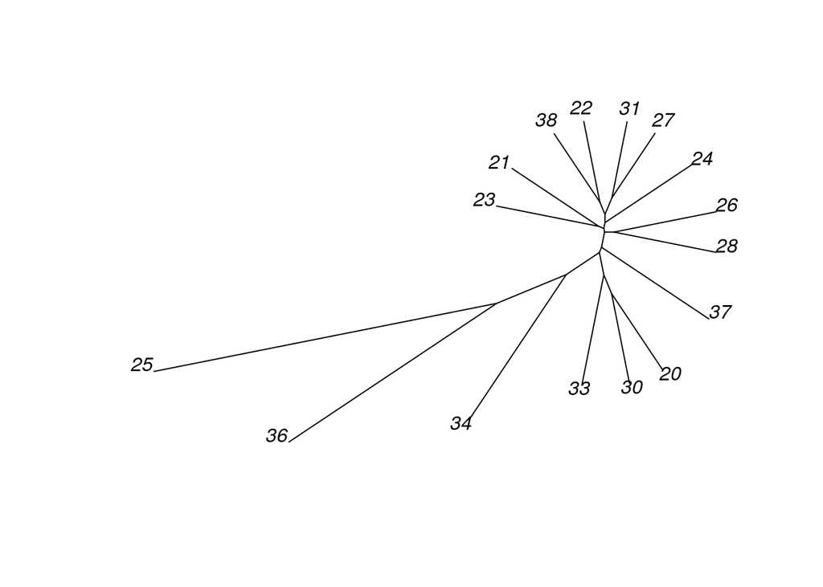

```r
plot(hc, type = "unroot")
```

Then a fan shaped tree

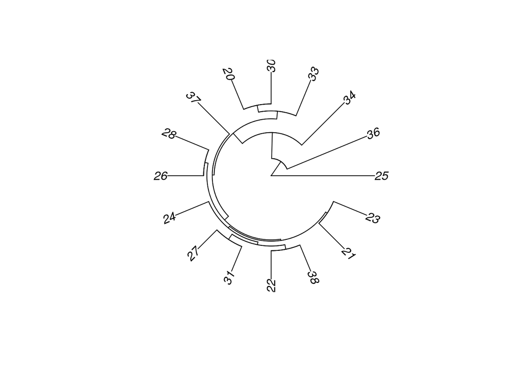

```r
plot(hc, type = "fan")
```

In the examples above the ends of the tree are labeled with the sample identifiers. It may be useful to illustrate another variable at the end of each node.

First read in the data about the farms

```r
my_data <- read.csv("prewmort.csv")
```

Collapse the data to one row per farm. In this case, we’ll use the `plyr` library and the `ddply` function to do the collapsing.

```r
library(plyr)

farm_level <- ddply(.data = my_data, .var = "herd", .fun = function(x){

    value <- unique(x$herdtype)
    stopifnot(length(value) == 1)
    return(data.frame("herdtype" = value))

})

farm_level
```

```
   herd herdtype
1    20        0
2    21        0
3    22        0
4    23        0
5    24        0
6    25        0
7    26        0
8    27        0
9    28        0
10   30        0
11   31        0
12   33        1
13   34        1
14   36        1
15   37        1
16   38        1
```

Generate a vector of the colours that you would like the symbols at each node to have. You have 2 herdtypes and therefore your vector should have 2 colours

```r
colours <- c("grey", "red")
```

Generate a two binary dummy variables for herd type

```r
farm_level$breeding <- 0
farm_level$breeding[farm_level$herdtype == 0] <- 1

farm_level$production <- 0
farm_level$production[farm_level$herdtype == 1] <- 1
```

generate a variable of how big each symbol should be. We’ll make them all the same size

```r
farm_level$pie_size <- rep(1, nrow(farm_level))
```

**IMPORTANT**: Order the dataframe according to the nodes in the tree. If you don’t do this the node labels will be incorrectly ordered.

```r
farm_level <- farm_level[match(hc$tip.label, farm_level$herd),]
```

Now the order matches

```r
hc$tip.label
```

```
 [1] "34" "37" "25" "28" "21" "36" "23" "33" "27" "24" "26" "30" "31" "22"
[15] "20" "38"
```

```r
farm_level
```

```
   herd herdtype breeding production pie_size
13   34        1        0          1        1
15   37        1        0          1        1
6    25        0        1          0        1
9    28        0        1          0        1
2    21        0        1          0        1
14   36        1        0          1        1
4    23        0        1          0        1
12   33        1        0          1        1
8    27        0        1          0        1
5    24        0        1          0        1
7    26        0        1          0        1
10   30        0        1          0        1
11   31        0        1          0        1
3    22        0        1          0        1
1    20        0        1          0        1
16   38        1        0          1        1
```

Generate a matrix of the node types to be used for colouring. The matrix must have row names that match the tiplabele of the clustering object `hc`. Generate a vector of pie_sizes in the same way.

```r
herd_type <- as.matrix(farm_level[,c("breeding", "production")])
rownames(herd_type) <- farm_level$herd

pie_size <- farm_level$pie_size
names(pie_size) <- farm_level$herd
```

Now we can use the values in `herd_type` to colour the tree

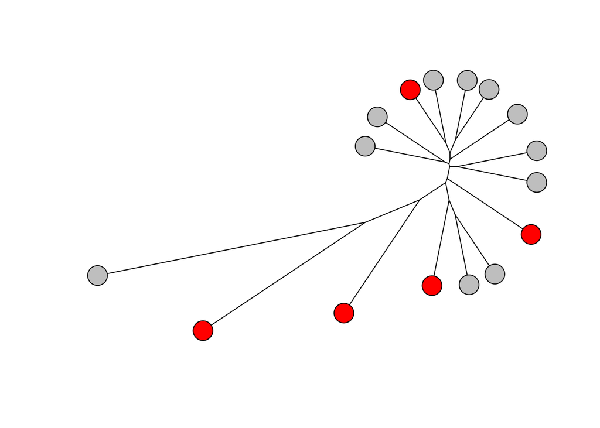

```r
plot(hc, type = "unroot", show.tip.label = FALSE)
tiplabels(pie = herd_type, piecol = colours, cex = pie_size)
```

Now you can experiment with the `pie_size` vector and `herd_type` matrix to see what else is possible.

Try to generate a tree with some bigger nodes. Perhaps you have a tree that illustrates multiple isolates at an end node and therefore you want to make the node size reflect the number of isolates at the node.

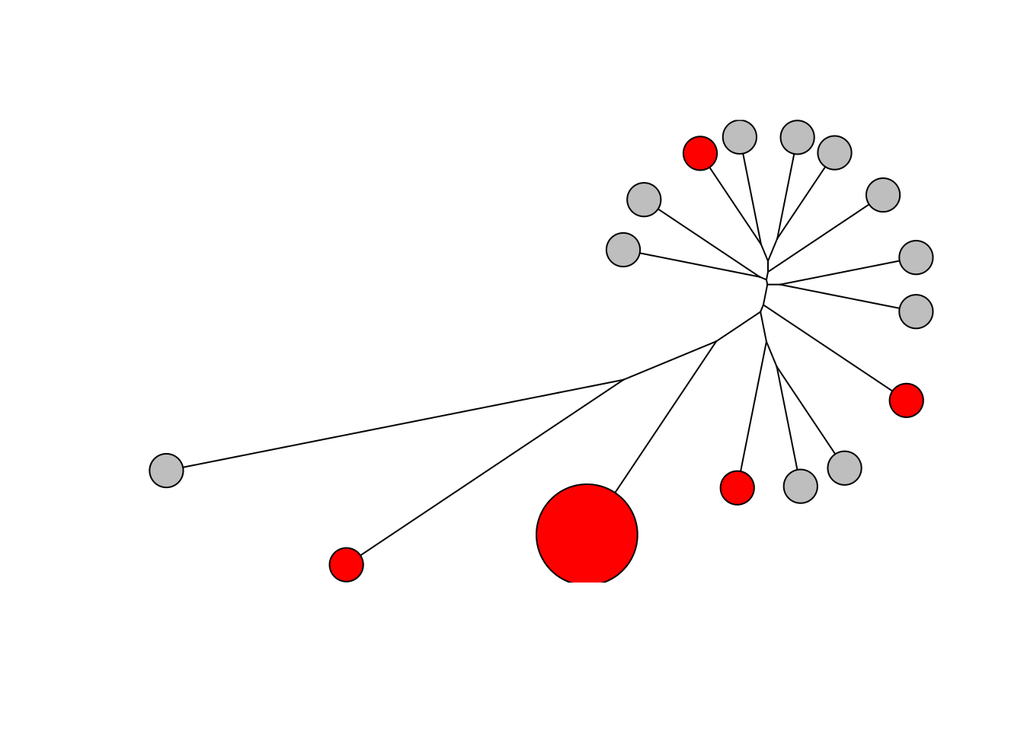

```r
pie_size[1] <- 3
plot(hc, type = "unroot", show.tip.label = FALSE)
tiplabels(pie = herd_type, piecol = colours, cex = pie_size)
```

And maybe that node has 2 production farms and 1 breeding farm

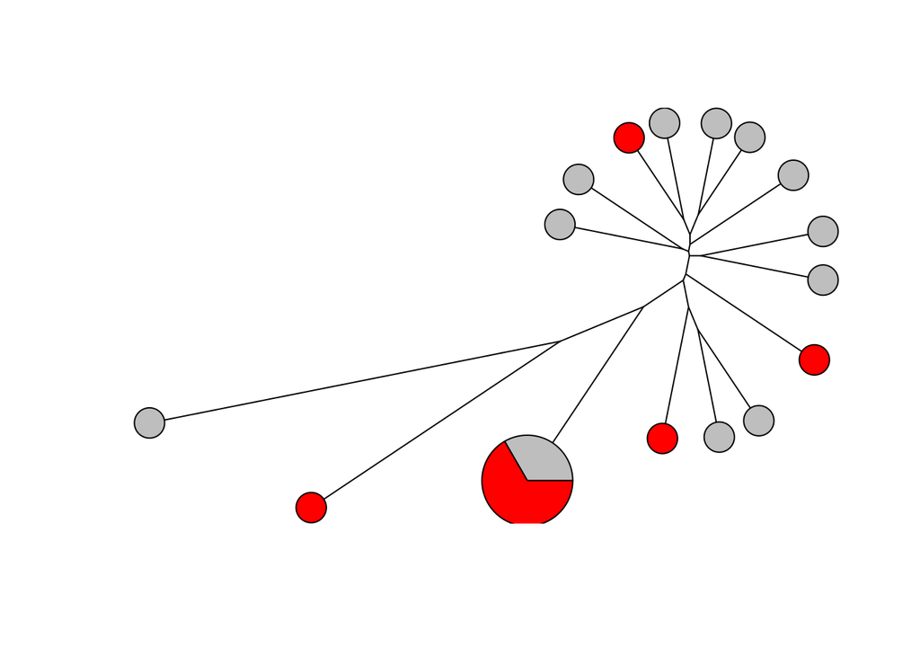

```r
herd_type[1,1] <- 1
herd_type[1,2] <- 2

plot(hc, type = "unroot", show.tip.label = FALSE)
tiplabels(pie = herd_type, piecol = colours, cex = pie_size)
```

## Now you try:

Change the size of the pie on node ‘5’ to be bigger and have 3 breeding farms and 1 production farm.